# CL_ECE5332_Report2

Caleb Leonard

September 26, 2025

## Retrospective Analysis of Silicon Wafer Resistivity

Previous to my employment of this semiconductor fabrication company, Y-Fab, 30 subgroups of 5 measurements of wafer resistivity (in ohm-cm) were taken, that will be denoted as retrospective resistivity, found at: “https://github.com/Caleb-Leonard/Statistical-Methods-in-Semiconductor-Manufacturing/blob/main/retrospective_resistivity.csv”. After loading this dataset into R, an initial X-Bar chart and a R Chart was constructed, shown below.

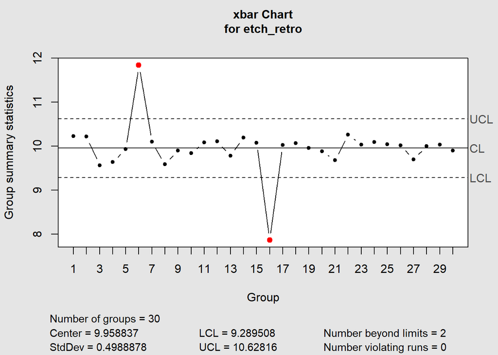

```
## List of 11
##  $ call      : language qcc(data = etch_retro, type = "xbar", sizes = 5)
##  $ type      : chr "xbar"
##  $ data.name : chr "etch_retro"
##  $ data      : num [1:30, 1:5] 10.25 9.88 9.77 9.72 10.73 ...
##   ..- attr(*, "dimnames")=List of 2
##  $ statistics: Named num [1:30] 10.23 10.22 9.57 9.64 9.93 ...
##   ..- attr(*, "names")= chr [1:30] "1" "2" "3" "4" ...
##  $ sizes     : num [1:30] 5 5 5 5 5 5 5 5 5 5 ...
##  $ center    : num 9.96
##  $ std.dev   : num 0.499
##  $ nsigmas   : num 3
##  $ limits    : num [1, 1:2] 9.29 10.63
##   ..- attr(*, "dimnames")=List of 2
##  $ violations:List of 2
##  - attr(*, "class")= chr "qcc"
```

```r
#Retrospective Analysis
etch_retro<-read.csv("https://raw.githubusercontent.com/Caleb-Leonard/Statistical-Methods-in-Semiconductor-Manufacturing/refs/heads/main/retrospective_resistivity.csv",
                    header=FALSE)

qcc(data=etch_retro,
    type="xbar",
    sizes=5)
```

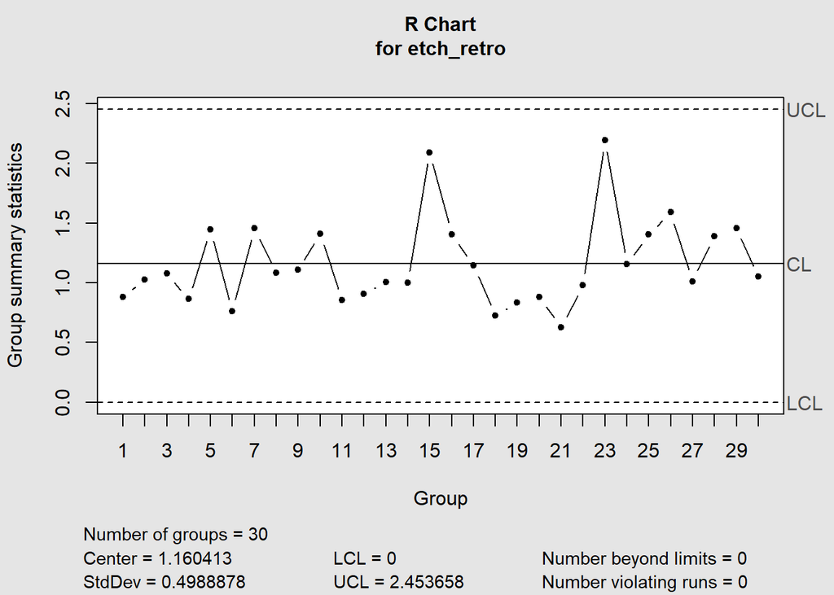

```
## List of 11
##  $ call      : language qcc(data = etch_retro, type = "R", sizes = 5)
##  $ type      : chr "R"
##  $ data.name : chr "etch_retro"
##  $ data      : num [1:30, 1:5] 10.25 9.88 9.77 9.72 10.73 ...
##   ..- attr(*, "dimnames")=List of 2
##  $ statistics: Named num [1:30] 0.879 1.024 1.078 0.863 1.445 ...
##   ..- attr(*, "names")= chr [1:30] "1" "2" "3" "4" ...
##  $ sizes     : num [1:30] 5 5 5 5 5 5 5 5 5 5 ...
##  $ center    : num 1.16
##  $ std.dev   : num 0.499
##  $ nsigmas   : num 3
##  $ limits    : num [1, 1:2] 0 2.45
##   ..- attr(*, "dimnames")=List of 2
##  $ violations:List of 2
##  - attr(*, "class")= chr "qcc"
```

```r
qcc(data=etch_retro,
    type="R",
    sizes=5)
```

Subgroup 6 and Subgroup 16 were deemed out-of-control, exceeding the upper control limit and the lower control limit respectively. These Subgroups were then excluded from the dataset, which is plotted in new X-Bar and R Charts below.

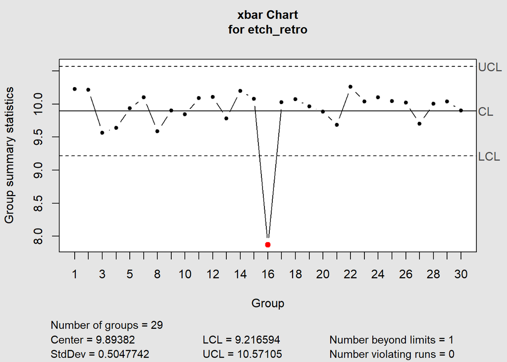

```
## List of 11
##  $ call      : language qcc(data = etch_retro, type = "xbar", sizes = 5)
##  $ type      : chr "xbar"
##  $ data.name : chr "etch_retro"
##  $ data      : num [1:29, 1:5] 10.25 9.88 9.77 9.72 10.73 ...
##   ..- attr(*, "dimnames")=List of 2
##  $ statistics: Named num [1:29] 10.23 10.22 9.57 9.64 9.93 ...
##   ..- attr(*, "names")= chr [1:29] "1" "2" "3" "4" ...
##  $ sizes     : num [1:29] 5 5 5 5 5 5 5 5 5 5 ...
##  $ center    : num 9.89
##  $ std.dev   : num 0.505
##  $ nsigmas   : num 3
##  $ limits    : num [1, 1:2] 9.22 10.57
##   ..- attr(*, "dimnames")=List of 2
##  $ violations:List of 2
##  - attr(*, "class")= chr "qcc"
```

```r
etch_retro<-etch_retro[-6,] #remove out-of-control subgroup 6

qcc(data=etch_retro,
    type="xbar",
    sizes=5)
```

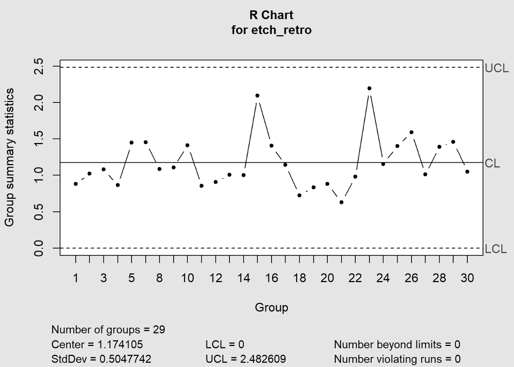

```
## List of 11
##  $ call      : language qcc(data = etch_retro, type = "R", sizes = 5)
##  $ type      : chr "R"
##  $ data.name : chr "etch_retro"
##  $ data      : num [1:29, 1:5] 10.25 9.88 9.77 9.72 10.73 ...
##   ..- attr(*, "dimnames")=List of 2
##  $ statistics: Named num [1:29] 0.879 1.024 1.078 0.863 1.445 ...
##   ..- attr(*, "names")= chr [1:29] "1" "2" "3" "4" ...
##  $ sizes     : num [1:29] 5 5 5 5 5 5 5 5 5 5 ...
##  $ center    : num 1.17
##  $ std.dev   : num 0.505
##  $ nsigmas   : num 3
##  $ limits    : num [1, 1:2] 0 2.48
##   ..- attr(*, "dimnames")=List of 2
##  $ violations:List of 2
##  - attr(*, "class")= chr "qcc"
```

```r
qcc(data=etch_retro,
    type="R",
    sizes=5)
```

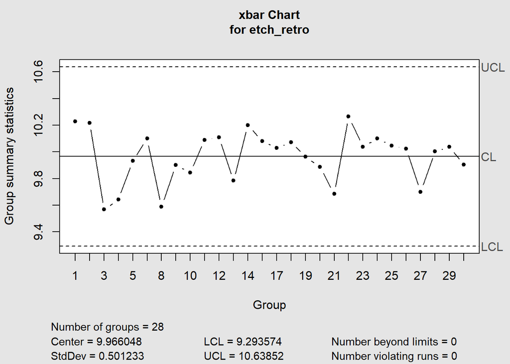

```
## List of 11
##  $ call      : language qcc(data = etch_retro, type = "xbar", sizes = 5)
##  $ type      : chr "xbar"
##  $ data.name : chr "etch_retro"
##  $ data      : num [1:28, 1:5] 10.25 9.88 9.77 9.72 10.73 ...
##   ..- attr(*, "dimnames")=List of 2
##  $ statistics: Named num [1:28] 10.23 10.22 9.57 9.64 9.93 ...
##   ..- attr(*, "names")= chr [1:28] "1" "2" "3" "4" ...
##  $ sizes     : num [1:28] 5 5 5 5 5 5 5 5 5 5 ...
##  $ center    : num 9.97
##  $ std.dev   : num 0.501
##  $ nsigmas   : num 3
##  $ limits    : num [1, 1:2] 9.29 10.64
##   ..- attr(*, "dimnames")=List of 2
##  $ violations:List of 2
##  - attr(*, "class")= chr "qcc"
```

```r
etch_retro<-etch_retro[-15,] #remove out-of-control subgroup 16, now subgroup 15 after removing subgroup 6

qcc(data=etch_retro,
    type="xbar",
    sizes=5)
```

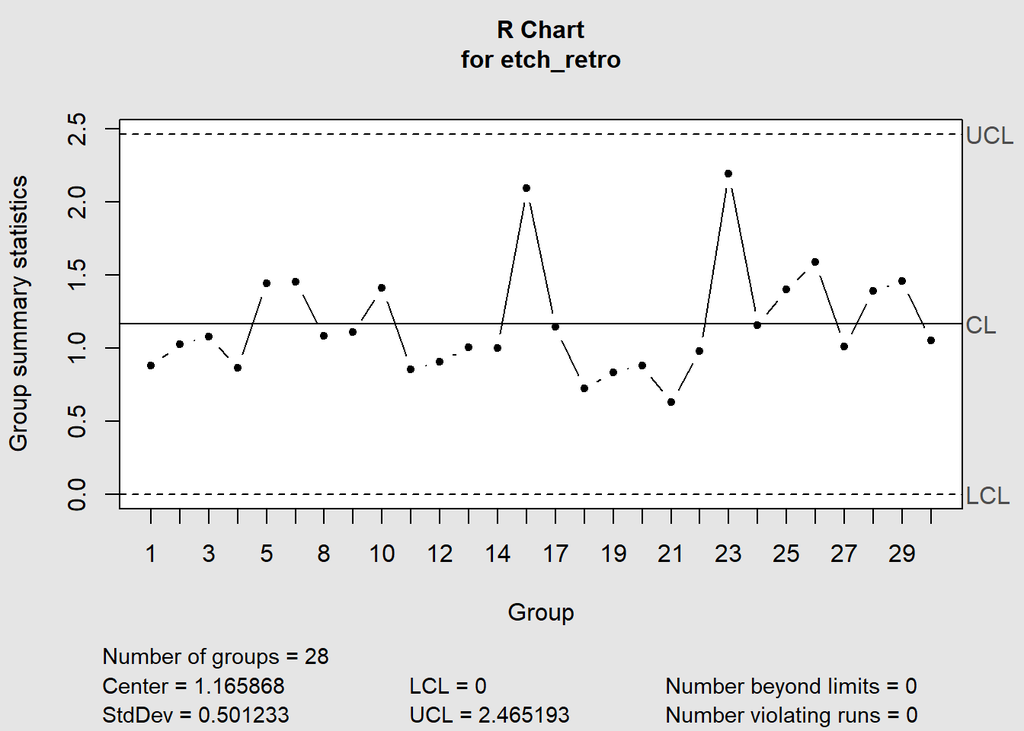

```
## List of 11
##  $ call      : language qcc(data = etch_retro, type = "R", sizes = 5)
##  $ type      : chr "R"
##  $ data.name : chr "etch_retro"
##  $ data      : num [1:28, 1:5] 10.25 9.88 9.77 9.72 10.73 ...
##   ..- attr(*, "dimnames")=List of 2
##  $ statistics: Named num [1:28] 0.879 1.024 1.078 0.863 1.445 ...
##   ..- attr(*, "names")= chr [1:28] "1" "2" "3" "4" ...
##  $ sizes     : num [1:28] 5 5 5 5 5 5 5 5 5 5 ...
##  $ center    : num 1.17
##  $ std.dev   : num 0.501
##  $ nsigmas   : num 3
##  $ limits    : num [1, 1:2] 0 2.47
##   ..- attr(*, "dimnames")=List of 2
##  $ violations:List of 2
##  - attr(*, "class")= chr "qcc"
```

```r
qcc(data=etch_retro,
    type="R",
    sizes=5)
```

## Online Analysis of Silicon Wafer Resistivity

Since the retrospective analysis was performed and new control limits were established, a new dataset of 10 subgroups of 5 measurements was taken. This dataset will be denoted as online resistivity, found at: “https://github.com/Caleb-Leonard/Statistical-Methods-in-Semiconductor-Manufacturing/blob/main/online_resistivity.csv”. After loading this dataset into R, an initial X-Bar chart and a R Chart was constructed, shown below. The X-Bar Chart as given a center of 9.966048 and standard deviation of 0.501233, both taken from the finalized Retrospective X-Bar Chart. The R Chart was given a center of 1.165868 and a standard deviation of 0.501233, both taken from the finalized Retrospective R Chart.

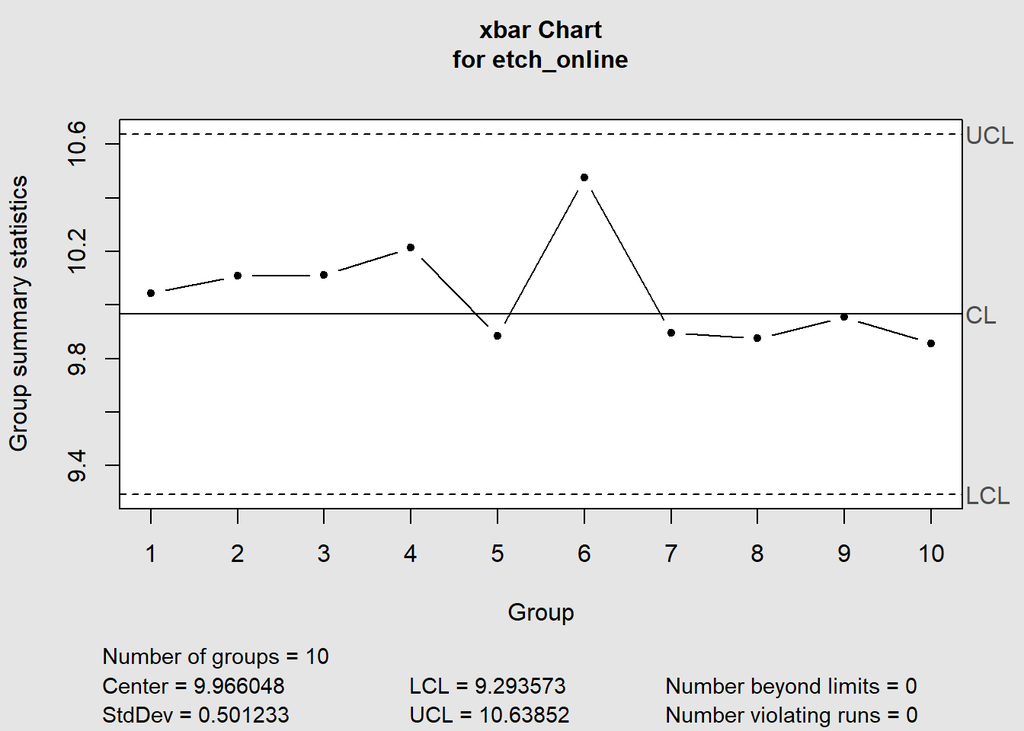

```
## List of 11
##  $ call      : language qcc(data = etch_online, type = "xbar", sizes = 5, center = 9.966048,      std.dev = 0.501233)
##  $ type      : chr "xbar"
##  $ data.name : chr "etch_online"
##  $ data      : num [1:10, 1:5] 10.13 9.64 9.51 10.21 9.56 ...
##   ..- attr(*, "dimnames")=List of 2
##  $ statistics: Named num [1:10] 10.04 10.11 10.11 10.21 9.88 ...
##   ..- attr(*, "names")= chr [1:10] "1" "2" "3" "4" ...
##  $ sizes     : num [1:10] 5 5 5 5 5 5 5 5 5 5
##  $ center    : num 9.97
##  $ std.dev   : num 0.501
##  $ nsigmas   : num 3
##  $ limits    : num [1, 1:2] 9.29 10.64
##   ..- attr(*, "dimnames")=List of 2
##  $ violations:List of 2
##  - attr(*, "class")= chr "qcc"
```

```r
#Online Analysis
etch_online<-read.csv("https://raw.githubusercontent.com/Caleb-Leonard/Statistical-Methods-in-Semiconductor-Manufacturing/refs/heads/main/online_resistivity.csv",
                    header=FALSE)

qcc(data=etch_online,
    type="xbar",
    sizes=5, center=9.966048,std.dev = 0.501233)
```

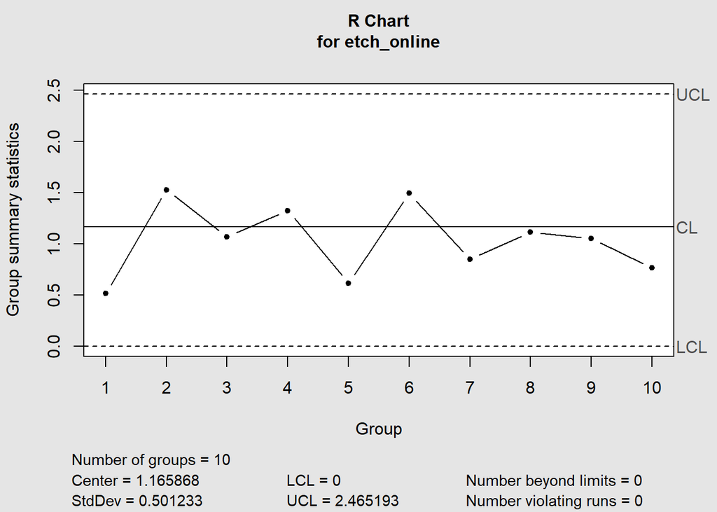

```
## List of 11
##  $ call      : language qcc(data = etch_online, type = "R", sizes = 5, center = 1.165868,      std.dev = 0.501233)
##  $ type      : chr "R"
##  $ data.name : chr "etch_online"
##  $ data      : num [1:10, 1:5] 10.13 9.64 9.51 10.21 9.56 ...
##   ..- attr(*, "dimnames")=List of 2
##  $ statistics: Named num [1:10] 0.513 1.529 1.067 1.325 0.615 ...
##   ..- attr(*, "names")= chr [1:10] "1" "2" "3" "4" ...
##  $ sizes     : num [1:10] 5 5 5 5 5 5 5 5 5 5
##  $ center    : num 1.17
##  $ std.dev   : num 0.501
##  $ nsigmas   : num 3
##  $ limits    : num [1, 1:2] 0 2.47
##   ..- attr(*, "dimnames")=List of 2
##  $ violations:List of 2
##  - attr(*, "class")= chr "qcc"
```

```r
qcc(data=etch_online,
    type="R",
    sizes=5, center=1.165868,std.dev = 0.501233)
```

While no Subgroups were deemed out-of-control, Subgroups 4 and 6 were noted due to their higher mean and Subgroups 1, 5, 7, and 10 were noted for their low range. The only sign that could show the process might be shifting out of control is the slope rate going from Subgroup 5 to 6 and from 6 to 7. This is not definitive as there is limited data to draw this conclusion from.